# 05.Example 2

Modified

Su 2026-09-13 19:38

## Given:

The engine cylinder of a motorcycle is constructed of 2024-T6 aluminum alloy is of height $0.15\ \mathrm{m}$ and outside diameter $50\ \mathrm{mm}$. Under typical operating conditions the outer surface of the cylinder is at a temperature of $500\ \mathrm{K}$ and is exposed to ambient air at $300\ \mathrm{K}$, with a convection coefficient of $50\ \frac{\mathrm{W}}{\left(\mathrm{K} \cdot \mathrm{m}^{2}\right)}$. Annular fins are integrally cast with the cylinder to increase heat transfer to the surroundings. Consider $5$ such fins, which are of thickness $6\ \mathrm{mm}$, length $20\ \mathrm{mm}$, and equally spaced.

## Required:

What is the increase in heat transfer due to use of the fins?

## Solution:

Start first by defining all of the given values.

$$H = 0.15\ \mathrm{m}$$
$$D = 50\ \mathrm{mm}$$
$$T_b = 500\ \mathrm{K}$$
$$T_{\infty} = 300\ \mathrm{K}$$
$$h = 50\ \frac{\mathrm{W}}{\left(\mathrm{K} \cdot \mathrm{m}^{2}\right)}$$
$$N = 5$$
$$t = 6\ \mathrm{mm}$$
$$L = 20\ \mathrm{mm}$$

A sketch of the cylinder is shown below.

Figure 1: System Diagram

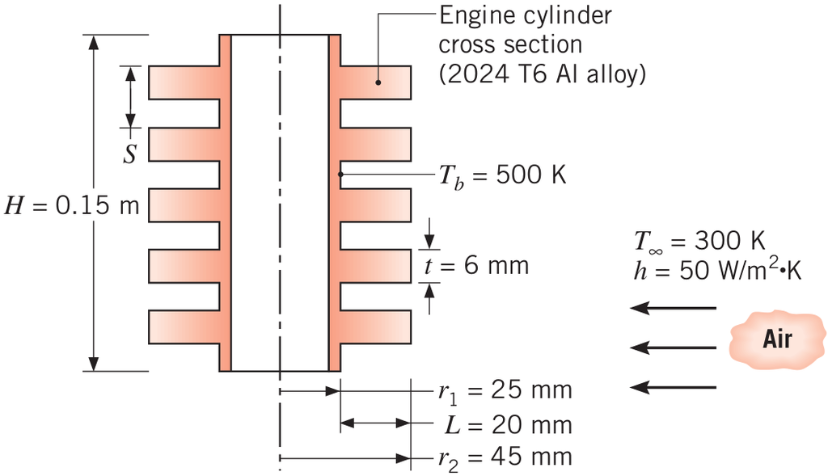

The diagram shows two radius variables that are particularly useful in the solution. These are defined below.

$$r_1 = \frac{D}{2} = 25.0\ \mathrm{mm}$$

$$r_2 = r_1 + L = 45.0\ \mathrm{mm}$$

Using the average temperature of $\bar{T}=\frac{T_b+T_\infty}{2}$ for the material properties, the thermal conductivity of 2024-T6 aluminum alloy may be found in Table A.1. This is defined below.

$$k = 186\ \frac{\mathrm{W}}{\left(\mathrm{K} \cdot \mathrm{m}\right)}$$

The two forms of the overall surface efficiency equation may be combined

$$\eta_o = \frac{q_t}{h A_t \theta_b} = 1 - \frac{N A_f}{A_t}\left( 1 - \eta_f \right)$$

Solving for the total heat rate of a fin array shows

$$q_t=h A_t \left[ 1- \frac{N A_f}{A_t} \left( 1 - \eta_f \right)\right]\theta_b$$

The fin area is given by

$$A_f = 2 \pi (r_2^2 - r_1^2) + 2 \pi r_2 t = 104.9\ \mathrm{cm}^{2}$$

The total area is then

$$A_t = N A_f + 2 \pi r_1 (H - N t) = 713.1\ \mathrm{cm}^{2}$$

The temperature difference at the base is found by

$$\theta_b = T_b-T_\infty = 200\ \mathrm{K}$$

To determine the fin efficiency, the summary plot for annular fins may be used. This plot requires three parameters be calculated. The first is the $L_c$ term. This is shown below.

$$L_c = L+\frac{t}{2} = 23.0\ \mathrm{mm}$$

The next parameter that is required is the $A_p$ term. This is shown below.

$$A_p = L_c t = 138.0\ \mathrm{mm}^{2}$$

Using these two parameters, the $x$-axis term of the fin efficiency chart may be determined. This is shown below.

$$L_c^{\frac{3}{2}} (\frac{h}{k A_p})^{\frac{1}{2}} = 0.154$$

The last required parameter is the radius ratio. This is shown below.

$$\frac{r_{2c}}{r_1}$$

where $r_{2c}$ is defined as

$$r_{2c}=r_2+\frac{t}{2}$$

These values are found below.

$$r_{2c} = r_2+\frac{t}{2} = 48.0\ \mathrm{mm}$$

$$\frac{r_{2c}}{r_1} = 1.92$$

The efficiency chart is shown below.

Figure 2: Fin Efficiency Chart

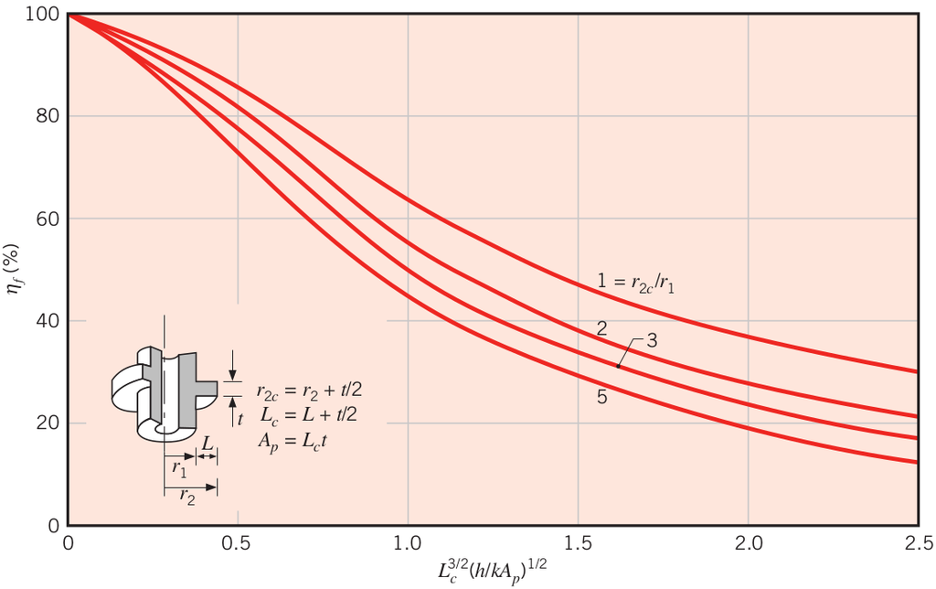

Reading the chart, it shows the fin efficiency is approximately

$$\eta_f \approx 0.9786 = 97.86 \%$$

**Note**

The value reported above was found using not the chart, but the governing equations which the chart uses. That is why the high degree of accuracy is shown (i.e., two decimal places).

The total heat rate is then found by

$$q_t = h A_t [1 - \frac{N A_f}{A_t} (1 - \eta_f)] \theta_b = 701.9\ \mathrm{W}$$

The total heat rate without the fins is found by

$$q_{wo} = h (2 \pi r_1 H) \theta_b = 235.6\ \mathrm{W}$$

The change in heat rate is then

$Answer: \Delta q = q_t-q_{wo} = 466.3\ \mathrm{W}$